# Solar Radiation EDA & prediction

Jonathan Bouchet

2020-09-05

```r
#options(width=100)
#knitr::opts_chunk$set(out.width='1000px',dpi=200,message=FALSE,warning=FALSE)
knitr::opts_chunk$set(message=FALSE,warning=FALSE)
```

```r
#load packages and csv file
library(ggplot2)
library(dplyr)
library(gridExtra)
library(Amelia)
library(corrplot)
library(ggfortify)
library(RColorBrewer)
library(forecast)
```

#EDA

```r
df<-read.csv("SolarPrediction.csv",sep = ",", dec = ".", header = TRUE)
any(is.na(df))
```

```
## [1] FALSE
```

```r
str(df)
```

```
## 'data.frame':    32686 obs. of  11 variables:
##  $ UNIXTime              : int  1475229326 1475229023 1475228726 1475228421 1475228124 1475227824 1475227519 1475227222 1475226922 1475226622 ...
##  $ Data                  : Factor w/ 118 levels "10/1/2016 12:00:00 AM",..: 111 111 111 111 111 111 111 111 111 111 ...
##  $ Time                  : Factor w/ 8299 levels "00:00:01","00:00:02",..: 8289 8258 8229 8195 8169 8142 8109 8086 8057 8028 ...
##  $ Radiation             : num  1.21 1.21 1.23 1.21 1.17 1.21 1.2 1.24 1.23 1.21 ...
##  $ Temperature           : int  48 48 48 48 48 48 49 49 49 49 ...
##  $ Pressure              : num  30.5 30.5 30.5 30.5 30.5 ...
##  $ Humidity              : int  59 58 57 60 62 64 72 71 80 85 ...
##  $ WindDirection.Degrees.: num  177 177 159 138 105 ...
##  $ Speed                 : num  5.62 3.37 3.37 3.37 5.62 5.62 6.75 5.62 4.5 4.5 ...
##  $ TimeSunRise           : Factor w/ 51 levels "06:07:00","06:08:00",..: 7 7 7 7 7 7 7 7 7 7 ...
##  $ TimeSunSet            : Factor w/ 56 levels "17:42:00","17:43:00",..: 31 31 31 31 31 31 31 31 31 31 ...
```

We need :

- to convert the `Data` feature to extract `year`,`month`,`day` and `hour` information
- to calculate the duration of the day, as the difference in time between `TimeSunSet` and `TimeSunRise`

##Utils

```r
getDate<-function(x,pos1,pos2){
  if(pos1==1){
  val<-as.numeric(strsplit(strsplit(as.character(x)," ")[[1]][pos1],'/')[[1]][pos2])
  }
  else if(pos1==3 & pos2==0){
    val<-as.factor(strsplit(strsplit(as.character(x)," ")[[1]][pos1],'/')[[1]])
  }
  return(val)
}

getTIME<-function(x,pos){
  val<-strsplit(as.character(x),":")[[1]][pos]
  return(as.numeric(val))
}
```

```r
df$Month<-sapply(df$Data,getDate,1,1)
df$Day<-sapply(df$Data,getDate,1,2)
df$Year<-sapply(df$Data,getDate,1,3)
df$TimeAbbr<-sapply(df$Data,getDate,3,0)
df$hour<-sapply(df$Time,getTIME,1)
df$minute<-sapply(df$Time,getTIME,2)
df$sec<-sapply(df$Time,getTIME,3)
head(df)
```

```
##     UNIXTime                  Data     Time Radiation Temperature Pressure
## 1 1475229326 9/29/2016 12:00:00 AM 23:55:26      1.21          48    30.46
## 2 1475229023 9/29/2016 12:00:00 AM 23:50:23      1.21          48    30.46
## 3 1475228726 9/29/2016 12:00:00 AM 23:45:26      1.23          48    30.46
## 4 1475228421 9/29/2016 12:00:00 AM 23:40:21      1.21          48    30.46
## 5 1475228124 9/29/2016 12:00:00 AM 23:35:24      1.17          48    30.46
## 6 1475227824 9/29/2016 12:00:00 AM 23:30:24      1.21          48    30.46
##   Humidity WindDirection.Degrees. Speed TimeSunRise TimeSunSet Month Day Year
## 1       59                 177.39  5.62    06:13:00   18:13:00     9  29 2016
## 2       58                 176.78  3.37    06:13:00   18:13:00     9  29 2016
## 3       57                 158.75  3.37    06:13:00   18:13:00     9  29 2016
## 4       60                 137.71  3.37    06:13:00   18:13:00     9  29 2016
## 5       62                 104.95  5.62    06:13:00   18:13:00     9  29 2016
## 6       64                 120.20  5.62    06:13:00   18:13:00     9  29 2016
##   TimeAbbr hour minute sec
## 1       AM   23     55  26
## 2       AM   23     50  23
## 3       AM   23     45  26
## 4       AM   23     40  21
## 5       AM   23     35  24
## 6       AM   23     30  24
```

```r
mymonths<-c("January","February","March","April","May","June","July","August","September","October","November","December")
df$MonthAbb <- mymonths[ df$Month ]
df$ordered_month <- factor(df$MonthAbb, levels = month.name)
#posixct for time serie
df$DateTs<-as.POSIXct(paste0(df$Year,'-',df$Month,'-',df$Day,' ',as.character(df$Time)), format="%Y-%m-%d %H:%M:%S")
df$DailyTs<-as.POSIXct(as.character(df$Time), format="%H:%M:%S")
df$DiffTime<-as.numeric(difftime(
  as.POSIXct(paste0(df$Year,'-',df$Month,'-',df$Day,' ',as.character(df$TimeSunSet)), format="%Y-%m-%d %H:%M:%S"),
  as.POSIXct(paste0(df$Year,'-',df$Month,'-',df$Day,' ',as.character(df$TimeSunRise)), format="%Y-%m-%d %H:%M:%S"),
  units='sec'))
```

##Radiation level

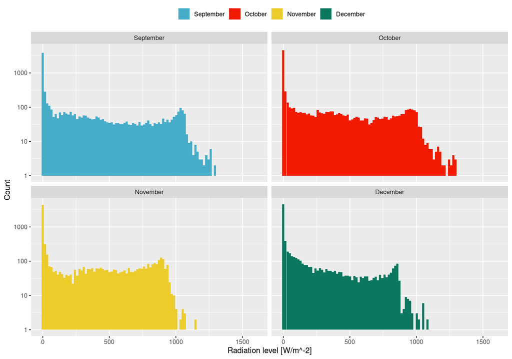

```r
ggplot(data=df,aes(x=Radiation,fill=ordered_month)) +
  geom_histogram(bins=100) +
  scale_y_log10() +
  scale_fill_manual(name="",values=c("#46ACC8","#F21A00","#EBCC2A","#0B775E")) +
  theme(legend.position='top') +
  facet_wrap(~ordered_month) +
  xlab('Radiation level [W/m^-2]') + ylab('Count')
```

Comments :

- we see a large peak for low Radiation (~0, meaning no Radiation) then smaller activity
- September is the month with a more pronounce peak at higher Radiation (>1000W/m^-2)

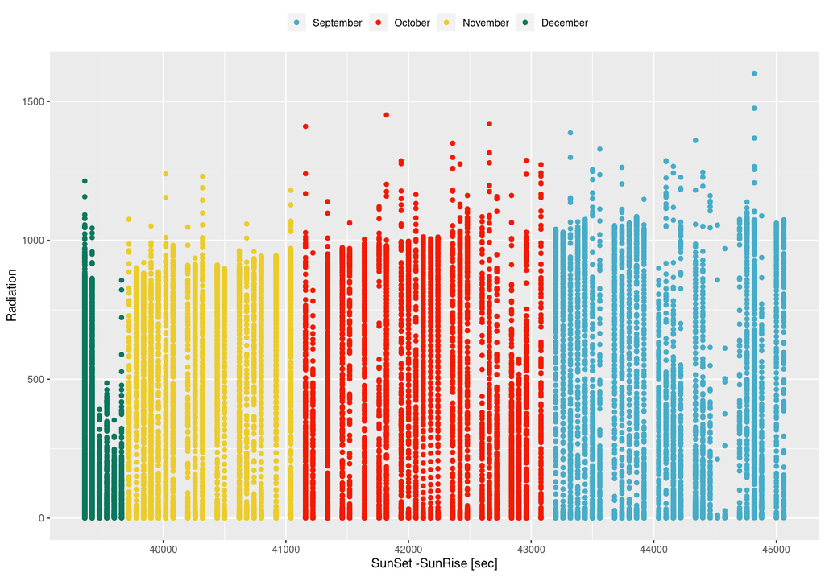

```r
ggplot(data=df,aes(x=DiffTime,y=Radiation)) +
  geom_point(aes(color=ordered_month)) +
  scale_color_manual(name="",values=c("#46ACC8","#F21A00","#EBCC2A","#0B775E")) +
  theme(legend.position='top') + xlab("SunSet -SunRise [sec]")
```

- This is an expected result : since the day is longer in September vs. all the other month, so the difference between sunrise and the sunset is longer
- it also seems that Radiation with higher level appear more often in September (or might just be a statistical issue, day longer so more probability to get a high Radiation)

##Mean Radiation per Day

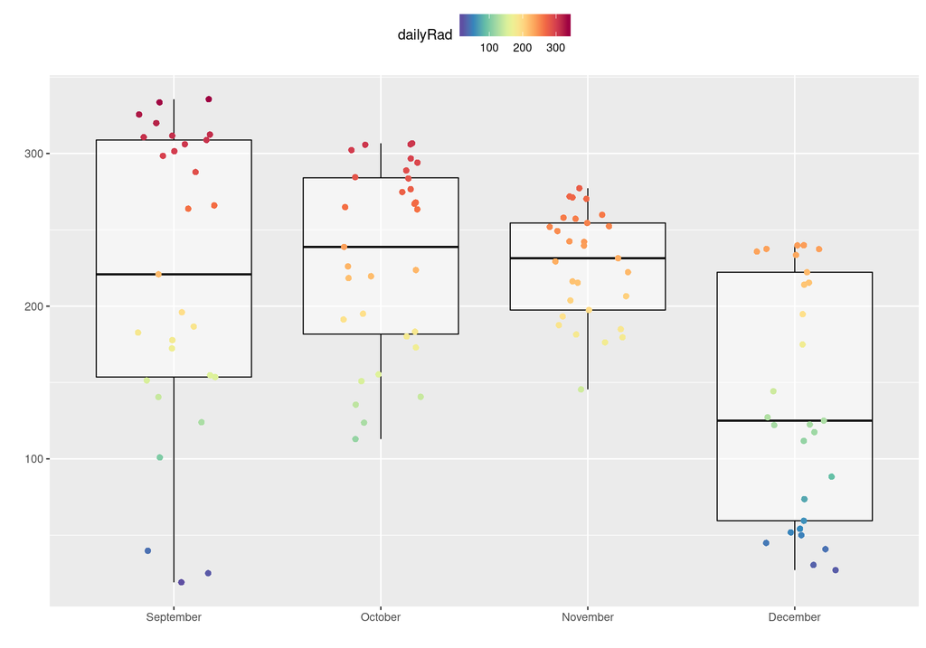

```r
df %>% select(ordered_month,Day,Radiation) %>%
  group_by(ordered_month,Day) %>%
  summarise(dailyRad = mean(Radiation)) %>%
  ggplot(aes(x=ordered_month,y=dailyRad,color=dailyRad)) +
  scale_color_gradientn(colours=rev(brewer.pal(10,'Spectral'))) +
  geom_boxplot(colour='black',size=.4,alpha=.5) +
  geom_jitter(shape=16,width=.2,size=2) +
  xlab('') + ylab('') + theme(legend.position='top')
```

###Radiation for a given day (as a test plot)

```r
ggplot(data=filter(df,Day==1 & ordered_month=='September'),aes(x=DateTs,y=Radiation)) +
  geom_line() + xlab('')
df %>% filter(Day==1 & ordered_month=='September') %>% summarise(mean(Radiation))
```

[output not shown]

##Time Serie

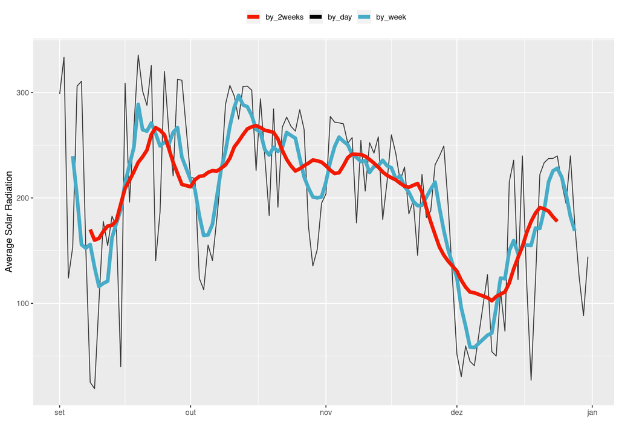

```r
dailyRadiation<-as.data.frame(df %>%
                                select(Month,Day,Radiation) %>%
                                group_by(Month,Day) %>%
                                summarise(dailyRad = mean(Radiation)))
#(re)create a Date format
dailyRadiation$dateTS<-as.Date(paste0('2016-',dailyRadiation$Month,'-',dailyRadiation$Day))
#weekly moving average
dailyRadiation$ma_week<-ma(dailyRadiation$dailyRad,order=7)
dailyRadiation$ma_2weeks<-ma(dailyRadiation$dailyRad,order=14)

ggplot() +
  geom_line(data=dailyRadiation,aes(x=dateTS,y=dailyRad,color='by_day'),alpha=.75) +
  geom_line(data=dailyRadiation,aes(x=dateTS,y=ma_week,color='by_week'),size=2) +
  geom_line(data=dailyRadiation,aes(x=dateTS,y=ma_2weeks,color='by_2weeks'),size=2) +
  xlab('') + ylab('Average Solar Radiation') +
  scale_colour_manual(name="",values=c(by_day="black",by_week="#46ACC8",by_2weeks="#F21A00")) +
  theme(legend.position='top')
```

- We may not have enough data to make a time serie analysis
- it seems (with this data) that we cannot identify any periodicity

#Prediction to do

**History :**

- *version 1 : initial commit*